# Week 1 Demonstration: Rendering an RMarkdown Report

PSYC40940

2026-09-24

# Aim

This document demonstrates the main RMarkdown features you will need in this module:

- section headings,
- R code chunks,
- inline R code,
- loading packages and data,
- rendering tables and figures,
- cross-referencing tables and figures,
- citing a source from a `.bib` file,
- rendering the document to HTML.

RMarkdown is useful because it keeps text, code, results, and figures in one reproducible document. This idea is closely related to literate programming (Knuth, 1984) and dynamic documents (Xie, 2017).

# Install Packages

RStudio includes Pandoc, which helps render RMarkdown files. The packages used in this document are separate R packages.

Only run this chunk if a package is missing. The chunk uses `eval=FALSE`, so the code is shown in the rendered HTML but is not run when the document renders.

```r
# This installs missing packages as a one-time setup step.
# eval=FALSE means this code is shown, but not run when knitting.
# Packages do not need to be installed every time the file is rendered.
install.packages(c("knitr", "rmarkdown", "bookdown"))
```

# Load Packages

Run this chunk before rendering to check that the packages are available.

```r
# tidyverse gives us read_csv(), select(), drop_na(), summarise(), arrange(), and ggplot().
library(tidyverse)

# knitr gives us kable(), which creates simple tables in rendered documents.
library(knitr)
```

# Load Data

We will use the `blomkvist.csv` dataset. These data come from a study on reaction time and ageing using the Nintendo Wii Balance Board (Blomkvist et al., 2017). The data are stored in the local `data` folder for this week.

```r
# Read the CSV file and store it in an object called blomkvist.
blomkvist <- read_csv("data/blomkvist.csv")
```

The dataset contains 267 rows and 10 columns. Inline R code is useful when values should update automatically if the data change.

# Inspect Data

Table 1 shows rows 1 to 6 of the dataset.

Table 1: Rows 1 to 6 of the Blomkvist dataset.

| id | sex | age | medicine | meds_cat | smoker | rt_hand_d | rt_hand_nd | rt_foot_d | rt_foot_nd |
| --- | --- | --- | --- | --- | --- | --- | --- | --- | --- |
| 1 | male | 84 | 8 | a lot | former | 701.6667 | 780.3333 | 1009.0000 | 962.6667 |
| 2 | female | 37 | 1 | little | no | 470.6667 | 497.0000 | 737.6667 | 692.3333 |
| 3 | female | 62 | 0 | none | yes | 638.6667 | 638.0000 | 878.0000 | 786.0000 |
| 4 | female | 85 | 4 | few | former | 708.0000 | 638.6667 | 902.3333 | 1373.6667 |
| 5 | male | 73 | 5 | a lot | former | 607.3333 | 652.0000 | 923.0000 | 805.0000 |
| 6 | male | 65 | 0 | none | no | 541.6667 | 498.6667 | 686.6667 | 599.6667 |

# Prepare Data

Here we keep a few variables and remove missing reaction-time values.

```r
# Keep only the variables used in this short report.
selected_data <- select(
  blomkvist,
  id,
  sex,
  age,
  smoker,
  rt_hand_d,
  rt_hand_nd
)

# Remove rows with missing values in either reaction-time variable.
plot_data <- drop_na(selected_data, rt_hand_d, rt_hand_nd)
```

After removing missing values, the plotting dataset contains 266 rows.

# Create a Figure

Figure 1 shows the relationship between reaction times for the dominant and non-dominant hand. The plot is included directly from the R code chunk.

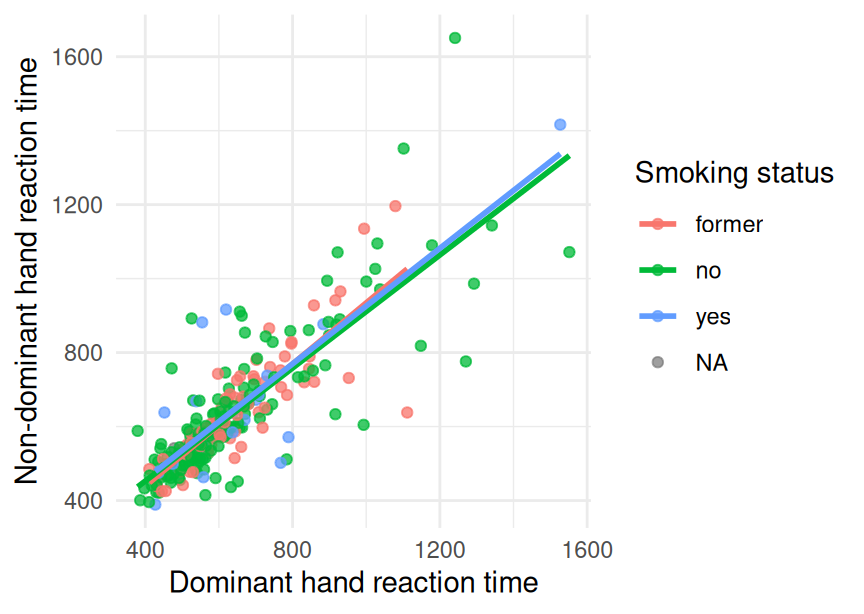

Figure 1: Reaction times for dominant and non-dominant hand responses.

```r
# Start with the data and define the variables used in the plot.
ggplot(plot_data, aes(x = rt_hand_d, y = rt_hand_nd, colour = smoker)) +
  geom_point(alpha = 0.75) +
  geom_smooth(method = "lm", se = FALSE) +
  labs(
    x = "Dominant hand reaction time",
    y = "Non-dominant hand reaction time",
    colour = "Smoking status"
  ) +
  theme_minimal()
```

# Create a Summary Table

Table 2 summarises the dominant-hand reaction times by smoking status.

```r
# Calculate descriptive statistics for each smoking-status group.
summary_table <- summarise(
  plot_data,
  mean_rt = mean(rt_hand_d),
  sd_rt = sd(rt_hand_d),
  n = n(),
  .by = smoker
)

# Put the table rows into a predictable order.
summary_table <- arrange(summary_table, smoker)

# Render the summary data frame as a table in the HTML output.
kable(
  summary_table,
  digits = 1,
  caption = "Dominant-hand reaction time by smoking status."
)
```

Table 2: Dominant-hand reaction time by smoking status.

| smoker | mean_rt | sd_rt | n |
| --- | --- | --- | --- |
| former | 652.5 | 152.1 | 76 |
| no | 634.6 | 202.7 | 163 |
| yes | 633.4 | 216.6 | 26 |
| NA | 478.7 | NA | 1 |

# Interpretation

The average dominant-hand reaction time in the cleaned dataset is 639 ms. When writing up visualisations, combine code-generated values with a short explanation of what the plot or table shows.

# How to Render

To render this document in RStudio:

1. Click **Knit**.
2. Check that the output HTML file appears in the same folder.
3. Open the HTML file and check that the table, figure, citations, and references appear correctly.

# References

Blomkvist, A. W., Eika, F., Rahbek, M. T., Eikhof, K. D., Hansen, M. D., Søndergaard, M., Ryg, J., Andersen, S., & Jørgensen, M. G. (2017). Reference data on reaction time and aging using the Nintendo Wii Balance Board: A cross-sectional study of 354 subjects from 20 to 99 years of age. *PLoS One*, *12*(12), e0189598.

Knuth, D. E. (1984). Literate programming. *The Computer Journal*, *27*(2), 97–111.

Xie, Y. (2017). *Dynamic documents with R and knitr*. Chapman; Hall/CRC.